# Projekt 6

Anna Wójcik, Dawid Dąbkowski, Grzegorz Ziajka

27 maja 2017

# 1 Podsumowanie

W tym etapie próbowaliśmy przeprowadzić transformację zmiennych objaśniających BOOKID i CNT oraz interakcji między tymi zmiennymi a płcią. Jedynie pogrupowanie interakcji między zmienną opisującą kraj i zmienną opisującą płeć poprawiło kryteria AIC oraz BIC, dlatego do dalszych analiz wybieramy ten model.

# 2 Przygotowanie danych

```r
library("agricolae")
library("ggplot2")
library("tidyr")
library("lmtest")
library("dplyr")
library("factorMerger")
```

```r
load("C:/Users/Anna/Downloads/actionTimeScoreGender.rda") # dane o zadaniach z matematyki plus plec

actionTimeScoreGender <- separate(actionTimeScoreGender, item_short, into = c('M', 'Q'), sep = 4)

actionTimeScoreGender$M <- as.factor(actionTimeScoreGender$M)
actionTimeScoreGender$Q <- as.factor(actionTimeScoreGender$Q)
actionTimeScoreGender$position <- replace(actionTimeScoreGender$position, actionTimeScoreGender$position==-1, NA)
actionTimeScoreGender$position <- droplevels(actionTimeScoreGender$position)

indeksy <- quantile(actionTimeScoreGender$T, probs=c(0.01, 0.99))
actionTimeScoreGender <- filter(actionTimeScoreGender, T <= indeksy[2])
actionTimeScoreGender <- filter(actionTimeScoreGender, T >= indeksy[1])

actionTimeScoreGender <- actionTimeScoreGender[complete.cases(actionTimeScoreGender),]

actionTimeScoreGenderSample <- sample_n(actionTimeScoreGender, 500000)
```

# 3 Przypomnienie wyjściowego modelu

Model, który wybraliśmy w poprzednich etapach zawiera sześć jakościowych zmiennych objaśniających.

```r
model1=lm(sqrt(T) ~position + M/Q+ST004D01T*CNT+ST004D01T*BOOKID, data = actionTimeScoreGenderSample)
```

```r
AIC(model1)
```

```
## [1] 2365196
```

```r
BIC(model1)
```

```
## [1] 2367954
```

# 4 Grupowanie zmiennej CNT

Spróbujemy pogrupować zmienną opisującą kraj ucznia i sprawdzimy czy poprawi to kryteria informacyjne.

```r
fm_CNT <- mergeFactors(sqrt(actionTimeScoreGenderSample$T), droplevels(actionTimeScoreGenderSample$CNT),method= "hclust",successive = TRUE,penalty=1)
```

```r
actionTimeScoreGenderSample$fm_CNT=cutTree(fm_CNT)
model=lm(sqrt(T) ~position+M/Q+ST004D01T*fm_CNT+ST004D01T*BOOKID, data = actionTimeScoreGenderSample)
AIC(model)
```

```
## [1] 2365379
```

```r
BIC(model)
```

```
## [1] 2367381
```

Grupowanie zmiennej opisującej kraj poprawiło kryterium BIC, ale pogorszyło kryterium AIC.

# 5 Grupowanie zmiennej BOOKID

Spróbujemy pogrupować zmienną opisującą indeks podręcznika i sprawdzimy czy poprawi to kryteria informacyjne.

```r
fm_BOOKID <- mergeFactors(sqrt(actionTimeScoreGenderSample$T), droplevels(actionTimeScoreGenderSample$BOOKID),successive = TRUE)
```

```r
actionTimeScoreGenderSample$fm_BOOKID=cutTree(fm_BOOKID)
model=lm(sqrt(T) ~position + M/Q+ST004D01T*CNT+ST004D01T*fm_BOOKID, data = actionTimeScoreGenderSample)
AIC(model)
```

```
## [1] 2365737
```

```r
BIC(model)
```

```
## [1] 2368084
```

Grupowanie zmiennej opisującej indeks podręcznika pogorszyło oba kryteria informacyjne.

# 6 Przygotowanie kolumn odpowiadających interakcjom

W powyższym modelu mamy do czynienia z dwiema interakcjami, między płcią a krajem oraz płcią a indeksem podręcznika. Spróbujemy połączyć podobne do siebie poziomy tych interakcji, by zmniejszyć liczbę parametrów modelu i poprawić tym samym kryteria informacyjne.

W tym celu przygotujemy kolumny, które będą odpowiadać interakcjom.

```r
actionTimeScoreGenderSample$CNT_SEX <- paste(actionTimeScoreGenderSample$CNT,actionTimeScoreGenderSample$ST004D01T, sep="_")
actionTimeScoreGenderSample$CNT_SEX<-as.factor(actionTimeScoreGenderSample$CNT_SEX)
```

```r
actionTimeScoreGenderSample$BOOKID_SEX <- paste(actionTimeScoreGenderSample$BOOKID,actionTimeScoreGenderSample$ST004D01T, sep="_")
actionTimeScoreGenderSample$BOOKID_SEX<-as.factor(actionTimeScoreGenderSample$BOOKID_SEX)
```

# 7 Grupowanie interakcji między krajem a płcią

Teraz pogrupujemy zmienną opisującą interakcję między krajem a płcią i sprawdzimy czy poprawi to kryteria informacyjne.

```r
fm_CNT_SEX <- mergeFactors(sqrt(actionTimeScoreGenderSample$T), droplevels(actionTimeScoreGenderSample$CNT_SEX),method= "hclust",successive = TRUE)
```

```r
actionTimeScoreGenderSample$fm_CNT_SEX=cutTree(fm_CNT_SEX)
model=lm(sqrt(T) ~position + M/Q+CNT+fm_CNT_SEX+ST004D01T*BOOKID, data = actionTimeScoreGenderSample)
AIC(model)
```

```
## [1] 2365155
```

```r
BIC(model)
```

```
## [1] 2367602
```

# 8 Grupowanie interakcji między indeksem podręcznika a płcią

Teraz badamy co stanie się po pogrupowaniu interakcji między indeksem podręcznika a płcią.

```r
fm_BOOKID_SEX <- mergeFactors(sqrt(actionTimeScoreGenderSample$T), droplevels(actionTimeScoreGenderSample$BOOKID_SEX),method= "hclust",successive = TRUE,penalty=2)
```

```r
actionTimeScoreGenderSample$fm_BOOKID_SEX=cutTree(fm_BOOKID_SEX)
model=lm(sqrt(T) ~position + M/Q+CNT+fm_BOOKID_SEX+ST004D01T*CNT, data = actionTimeScoreGenderSample)
AIC(model)
```

```
## [1] 2365945
```

```r
BIC(model)
```

```
## [1] 2368191
```

Kryteria informacyjne w porównaniu z wyjściowym modelem pogorszyły się.

# 9 Wizualizacja grupowania

Jedynie grupowanie interakcji między zmiennymi opisującymi kraj i płeć poprawiło oba kryteria informacyjne, dlatego ten model wybieramy do dalszych analiz oraz przedstawimy wizualizację wybranego grupowania.

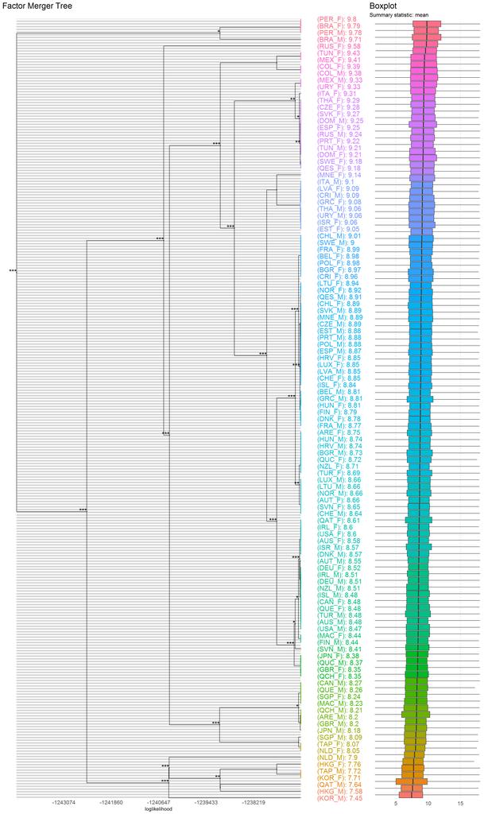

```r
plot(fm_CNT_SEX,color=TRUE,panel="response", responsePanel="boxplot")
```

Na powyższym wykresie pudełkowym możemy zobaczyć, w jaki sposób poziomy zostały ze sobą połączone.Ten sam kolor oznacza jeden poziom zmiennej fm_CNT_SEX. Liczba parametrów modelu spadła z 330 do 220 w porównaniu z modelem wyjściowym.